# Week 4: Sleep and Next-Day Glucose

Author

Tyler Tong

Published

August 10, 2026

# 1 Preparation

## 1.1 Load packages and locate inputs

```r
rm(list = ls())

library(conflicted)
library(tidyverse)
library(here)
library(jsonlite)
library(janitor)
library(knitr)
library(scales)
library(broom)

options(
  dplyr.summarise.inform = FALSE,
  scipen = 999
)

theme_set(
  theme_minimal(base_size = 12) +
    theme(
      plot.title.position = "plot",
      panel.grid.minor = element_blank()
    )
)

dataset_version <- "v3-mini"

data_dir <- paste0("/Users/tt/Library/CloudStorage/Box-Box/ai-readi/", dataset_version, "/dataset")

derived_dir <- here("practice", "derived")
dir.create(derived_dir, recursive = TRUE, showWarnings = FALSE)

sleep_input_path <- file.path(
  derived_dir,
  "week3_person_night_sleep.csv"
)

activity_input_path <- file.path(
  derived_dir,
  "week3_daily_activity.csv"
)

cgm_input_path <- file.path(
  derived_dir,
  "week2_participant_day_cgm.csv"
)

if (!file.exists(sleep_input_path) || !file.exists(activity_input_path)) {
  stop(
    "Run 03_sleep_activity_processing.qmd first; its two processed ",
    "tables are required for Week 4."
  )
}

resolve_data_path <- function(relative_path) {
  file.path(data_dir, str_remove(relative_path, "^/"))
}
```

## 1.2 Define the analysis rules

```r
study_group_labels <- c(
  healthy = "Healthy",
  pre_diabetes_lifestyle_controlled = "Pre-DM / lifestyle",
  oral_medication_and_or_non_insulin_injectable_medication_controlled =
    "Oral/non-insulin medication",
  insulin_dependent = "Insulin-dependent"
)
```

# 2 Read Week 3 tables and participant data

```r
person_night_sleep <- read_csv(
  sleep_input_path,
  show_col_types = FALSE
) |>
  mutate(
    person_id = as.character(person_id),
    sleep_night = as.Date(sleep_night),
    bedtime_utc = ymd_hms(bedtime_utc, tz = "UTC"),
    wake_time_utc = ymd_hms(wake_time_utc, tz = "UTC"),
    study_group_label = factor(
      study_group_label,
      levels = unname(study_group_labels)
    ),
    date = date(wake_time_local)
  )

daily_activity <- read_csv(
  activity_input_path,
  show_col_types = FALSE
) |>
  mutate(
    person_id = as.character(person_id),
    date = as.Date(date),
    study_group_label = factor(
      study_group_label,
      levels = unname(study_group_labels)
    )
  )

person_day_cgm <- read_csv(
  cgm_input_path,
  show_col_types = FALSE
) |>
  mutate(
    person_id = as.character(person_id),
    date_local = as.Date(date_local)
  )
```

# 3 Prepare and Join Inputs

## 3.1 Prepare Inputs

```r
person_day_cgm <- person_day_cgm |>
  rename(date = date_local) |>
  group_by(person_id, date) |>
  mutate(
    glucose_cv = (sd_glucose / mean_glucose) * 100
  ) |>
  ungroup()
person_night_sleep <- person_night_sleep |> mutate(
  bedtime_local = ymd_hms(bedtime_local),
  sleep_onset_local = ymd_hms(sleep_onset_local),
  final_sleep_end_local = ymd_hms(final_sleep_end_local),
  wake_time_local = ymd_hms(wake_time_local)
  )
daily_activity <- daily_activity |>
  select(!study_group) |>
  select(!clinical_site) |>
  select(!study_group_label)
glimpse(daily_activity)
```

```
Rows: 1,880
Columns: 10
$ person_id                    <chr> "1029", "1029", "1029", "1029", "1029", "…
$ date                         <date> 2023-09-07, 2023-09-08, 2023-09-09, 2023…
$ total_steps                  <dbl> 2244, 9189, 8102, 17890, 7917, 8058, 9482…
$ active_calories              <dbl> 103, 683, 165, 791, 531, 201, 656, 615, 2…
$ average_heart_rate_bpm       <dbl> 66.70814, 72.32969, 67.73670, 79.14354, 6…
$ step_observation_hours       <dbl> 13.283333, 24.000000, 24.000000, 24.00000…
$ valid_activity_day           <lgl> FALSE, TRUE, TRUE, TRUE, TRUE, TRUE, TRUE…
$ number_of_step_records       <dbl> 207, 366, 446, 429, 396, 369, 363, 377, 4…
$ number_of_calorie_records    <dbl> 39, 119, 130, 175, 106, 115, 129, 109, 11…
$ number_of_heart_rate_records <dbl> 442, 1098, 1090, 1045, 1104, 952, 988, 10…
```

## 3.2 Find unmatched participant-dates

```r
dfs <- list(person_day_cgm = person_day_cgm, person_night_sleep = person_night_sleep, daily_activity = daily_activity)
nms <- names(dfs)

key_long <- dfs |>
  map(\(d) d |>
        mutate(date = as.Date(date)) |>
        dplyr::filter(!is.na(person_id), !is.na(date)) |>
        distinct(person_id, date)) |>
  list_rbind(names_to = "source")

incomplete <- key_long |>
  summarise(sources = list(unique(source)), .by = c(person_id, "date")) |>
  dplyr::filter(lengths(sources) < length(nms)) |>
  mutate(
    present_in   = map_chr(sources, str_flatten, collapse = ", "),
    missing_from = map_chr(sources, \(s) str_flatten(setdiff(nms, s), ", "))
  ) |>
  select(person_id, date, present_in, missing_from) |>
  arrange(person_id, date)

glimpse(incomplete)
```

```
Rows: 1,193
Columns: 4
$ person_id    <chr> "1029", "1029", "1029", "1029", "1029", "1042", "1042", "…
$ date         <date> 2023-09-07, 2023-09-13, 2023-09-17, 2023-09-18, 2023-09-…
$ present_in   <chr> "daily_activity", "person_day_cgm, daily_activity", "pers…
$ missing_from <chr> "person_day_cgm, person_night_sleep", "person_night_sleep…
```

```r
bad_keys <- incomplete |>
  select(person_id, date)

dfs <- dfs |>
  map(\(d) anti_join(d, bad_keys,
                     by = join_by(person_id, date == date)))
```

## 3.3 Join `inputs` on `person_id` and `date`

```r
data <- dfs$person_day_cgm |>
  left_join(dfs$person_night_sleep, by = join_by(
    person_id == person_id,
    date == date
  )) |>
  left_join(dfs$daily_activity, by = join_by(
    person_id == person_id,
    date == date
  ))
glimpse(data)
```

```
Rows: 721
Columns: 52
$ person_id                       <chr> "1029", "1029", "1029", "1029", "1029"…
$ date                            <date> 2023-09-08, 2023-09-09, 2023-09-10, 2…
$ n_readings                      <dbl> 288, 288, 288, 288, 288, 288, 288, 288…
$ pct_expected                    <dbl> 100.00000, 100.00000, 100.00000, 100.0…
$ mean_glucose                    <dbl> 109.5000, 114.3646, 111.4688, 112.2292…
$ sd_glucose                      <dbl> 13.613889, 9.161486, 10.173361, 13.488…
$ pct_70_180                      <dbl> 100.00000, 100.00000, 100.00000, 100.0…
$ pct_above_180                   <dbl> 0.0000000, 0.0000000, 0.0000000, 0.000…
$ pct_below_70                    <dbl> 0.0000000, 0.0000000, 0.0000000, 0.000…
$ n_daytime                       <dbl> 216, 216, 216, 216, 216, 216, 216, 216…
$ n_nighttime                     <dbl> 72, 72, 72, 72, 72, 72, 72, 72, 72, 67…
$ mean_glucose_daytime            <dbl> 106.76852, 114.81481, 110.87500, 111.1…
$ mean_glucose_nighttime          <dbl> 117.6944, 113.0139, 113.2500, 115.4583…
```

[output cut: 39 more lines]

# 4 Build the Participant-level Analysis Table

## 4.1 Build the table from `data` using `summarize()`

```r
participant_table <- data |>
  ungroup() |>
  group_by(person_id) |>
  summarize(
    num_days                     = n(),
    typical_sleep_dur_min        = median(total_sleep_time_minutes),
    typical_daily_steps          = median(total_steps),
    typical_daily_glucose_cv     = median(glucose_cv),
    typical_daily_time_in_range  = median(pct_70_180) * 14.40,
    .groups = "drop"
  )
```

We use `median()` here because the data is likely to be skewed and asymmetric, making it less suitable for `mean()`.

## 4.2 Preview the analysis table

```r
kable(
  head(participant_table),
  col.names = c("ID",
                "Days",
                "Typical Sleep Duration",
                "Typical Daily Steps",
                "Typical Daily Glucose CV",
                "Typical Daily Time In Range"),
  align = "cccccc",
  digits = 2,
  caption = "First Six Rows of the Participant Analysis Table"
  )
```

First Six Rows of the Participant Analysis Table

| ID | Days | Typical Sleep Duration | Typical Daily Steps | Typical Daily Glucose CV | Typical Daily Time In Range |
| --- | --- | --- | --- | --- | --- |
| 1029 | 8 | 386.5 | 7987.5 | 8.93 | 1440 |
| 1042 | 7 | 382.0 | 20033.0 | 17.14 | 1425 |
| 1046 | 9 | 345.0 | 13490.0 | 16.18 | 1440 |
| 1054 | 9 | 415.0 | 9242.0 | 18.20 | 1380 |
| 1055 | 9 | 426.0 | 10209.0 | 15.14 | 1440 |
| 1073 | 7 | 307.0 | 8841.0 | 30.69 | 530 |

# 5 Create Participant Level Plots

## 5.1 Seep Duration vs. Glucose CV

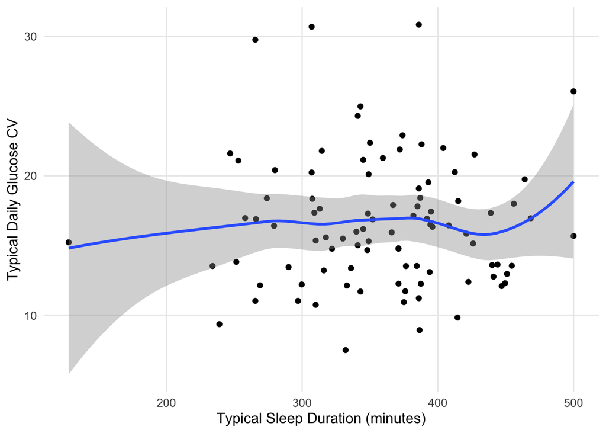

```r
participant_table |>
ggplot(
  aes(
    x = typical_sleep_dur_min,
    y = typical_daily_glucose_cv
  )
) +
  geom_point() +
  geom_smooth() +
  labs(x = "Typical Sleep Duration (minutes)", y = "Typical Daily Glucose CV")
```

```r
correlation_data_sleep <- tidy(cor.test(
  participant_table$typical_sleep_dur_min,
  participant_table$typical_daily_glucose_cv,
  method = "spearman"
  )) |>
  select(estimate, p.value) |>
  mutate(num_participants = nrow(participant_table))

kable(
  correlation_data_sleep,
  col.names = c("Spearman Estimate", "P Value", "Participant Count"),
  align = "ccc",
  digits = 3
  )
```

| Spearman Estimate | P Value | Participant Count |
| --- | --- | --- |
| 0.013 | 0.903 | 94 |

As seen in the `geom_smooth()` line, the relationship between sleep duration and glucose CV is very small. This is also reflected by the Spearman estimate, 0.0128028, which is near zero, showing that any linear correlation, if extant, is very weak. In addition, the p value is 0.9025251, which is near 1, meaning that there is no strong evidence that any correlation exists. The sample size is also relatively large, 94, so the results should not be because of a small sample size.

## 5.2 Daily Steps vs. Glucose CV

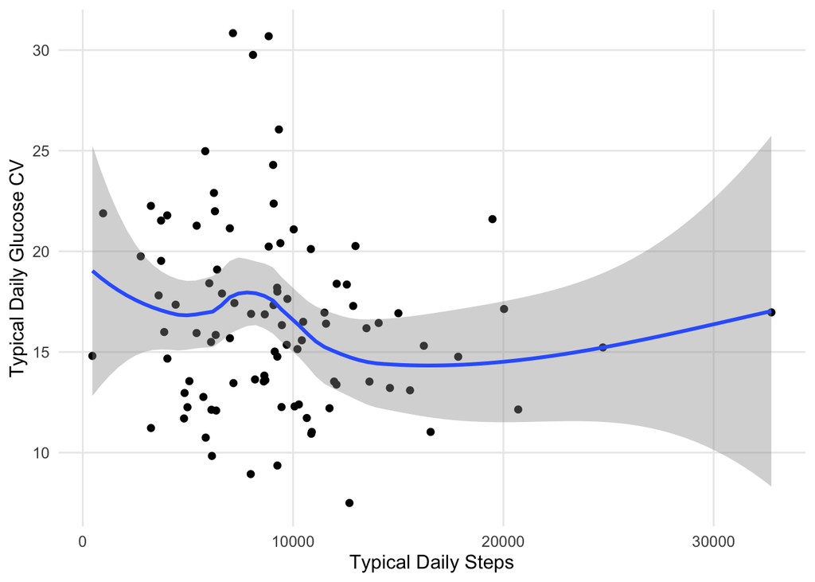

```r
participant_table |>
ggplot(
  aes(
    x = typical_daily_steps,
    y = typical_daily_glucose_cv
  )
) +
  geom_point() +
  geom_smooth() +
  labs(x = "Typical Daily Steps", y = "Typical Daily Glucose CV")
```

```r
correlation_data_steps <- tidy(cor.test(
  participant_table$typical_daily_steps,
  participant_table$typical_daily_glucose_cv,
  method = "spearman"
  )) |>
  select(estimate, p.value) |>
  mutate(num_participants = nrow(participant_table))

kable(
  correlation_data_steps,
  col.names = c("Spearman Estimate", "P Value", "Participant Count"),
  align = "ccc",
  digits = 3
  )
```

| Spearman Estimate | P Value | Participant Count |
| --- | --- | --- |
| -0.16 | 0.122 | 94 |

# 6 Interpretation

## 6.1 Which association is stronger in absolute magnitude?

The association between daily steps and glucose CV is stronger than that between sleep duration and glucose CV(0.1604378 > 0.0128028).

## 6.2 What does the direction of each correlation mean?

The association of daily steps and glucose CV is negative(-0.1604378 < 0), meaning that as daily steps increase, glucose CV should decrease. On the other hand, the association between sleep duration and glucose CV is positive(0.0128028 > 0), meaning that as sleep duration increases, glucose CV should increase.